# =====================================

# 9A-L1 Color Spaces

# =====================================

## Cones

### Light Detection: Rods and Cones

[figure not shown]

Fig 1(a): anatomybox.com/retina-sem

Cones:

- 6-7 million cones in the retina
- Responsible for high-resolution vision
- Discriminate $\color{red}{c}\color{maroon}{o}\color{blue}{l}\color{green}{o}\color{pink}{r}\color{yellow}{s}$
- There are three types of color sensors: $64\%\,\color{red}{\text{ red, }}32\%\color{green}{\text{ green, }}2\%\color{blue}{\text{ blue}}$

[figure not shown]

Fig 1(b)

[figure not shown]

Fig 1(c): Retina Mosaic

## Wait!!! I am going to the Camp Nue for FC Barcelona vs Liverpool FC champions league semi-final match. I will be back in a minute

## Waaaaaaaaaaaaaaaaaaw. What a game!!!. I am speachless. People asks me are you really going to spend all that money and time to watch a football match, and Messi answers them from the field: I will pay him off every single second and every single penny. Gracias Messi.

## Messi scored his 600 goal with Barcelona in the most astonishing way. While I was hesitant at the begining (because it was a long shot), fortunately, I took my mobile out and recorded it

```python
# Uncomment the below code and run to enjoy.
# Comment it out back and run before exiting
# as this might cause the notebook to crash
# in the next time you open it

# from IPython.display import HTML
# HTML("""
# <br/>
# <center><font color="red" size="16px">Messi. Messi. Messi.</font></center>
# <center>
# <video controls width="620" height="440" src="imgs/messi_magic.mov" type="video/mp4">
# </video>
# </center>
# <br/>

# """)
```

## Tristimulus Color Theory

[figure not shown]

Fig 2: Percentage of light absorbed by each cone

Spectral-response functions of each of the three types of cones

- Can we use them to match any spectral color?

[figure not shown]

## Color Matching Function Based on RGB

Most spectral color can be represented as a positive linear combination of these primary colors(but..)

But some spectral cannot - need to add some red

[figure not shown]

Fig 3(a)

[figure not shown]

Fig 3(b)

## Color is a Psychological Phenomenon

green triggers green cone more than red cone, red triggers red cone more than green cone, when the two cones are balanced, the human vision can't tell the difference

[figure not shown]

Fig 4: red + green = yellow

## Luminance vs Color

[figure not shown]

Fig 5

## CIE RGB Color Space

Color matching experiments [Wright & Cuild 1920s]

- Mapped physical wavelengths to perceived colors
- Identified relative similarity and difference between colors
- Result: CIE RGB space defined

### Color perceivable by the human eye

[figure not shown]

Fig 6: CIE xy chromaticity diagram, 1931

### CIE XYZ color space

A new space with desired properties

- Easy to computer - linear trasform of CIE RGB
- Y: Perceived luminance
- X, Z: Perceived color
- Represents a wide range of colors

$$x = \frac{X}{X+Y+Z}$$

$$y = \frac{Y}{X+Y+Z}$$

## CIE $\color{blue}{L*a*b*}$ Color Space

[figure not shown]

Fig 7(a)

### Cylindrical view

Think of chroma (here a*,b*) defining a planar disc at each luminance level (L)

[figure not shown]

Fig 7(b)

### HSL and HSV color space

[figure not shown]

Fig 7(c)

### Quiz

If hue values range in [0, 360], what is the absolute difference between the following pairs of hues?

- 225 and 75: 150
- 45 and 315: 90

## Other Color Spaces

### But there are lots of color spaces

[figure not shown]

Fig 8(a)

### Instructor favorite

[figure not shown]

Fig 8(b)

### The one we know best...

- RGB color space

[figure not shown]

Fig 8(c)

### Like a squared double cone?

[figure not shown]

Fig 8(d)

## Color Gamuts

[figure not shown]

Fig 9(a)

[figure not shown]

Fig 9(b)

[figure not shown]

Fig 9(c)

[figure not shown]

Fig 9(d)

## Revisiting Pixels

"Picture element" at location $\color{blue}{(x,y)}$, value or color $\color{blue}{c}$

[figure not shown]

Fig 10(a)

### Color values are vectors, here ($\color{red}{R}$, $\color{green}{G}$, $\color{blue}{B}$)

[figure not shown]

Fig 10(b)

[figure not shown]

Fig 10(c)

[figure not shown]

Fig 10(d)

### Quiz: Plotting Pixels in a Color Space Quiz

What does this view enable us to do?

- Think about clusters of pixels that are similar in color
- Understand the shape and size of objects present
- Identify pixels that are different, and seperate them
- Count how many pixels of each color there are

```python
%matplotlib inline
import cv2 as cv
import matplotlib.pyplot as plt
import numpy as np
from mpl_toolkits.mplot3d import Axes3D
from IPython.display import clear_output, Image as NoteImage, display
import PIL
from io import BytesIO
def imshow(im,fmt='jpeg'):
    #a = np.uint8(np.clip(im, 0, 255))
    f = BytesIO()
    PIL.Image.fromarray(im).save(f, fmt)
    display(NoteImage(data=f.getvalue()))
def imsave(im,filename,fmt='jpeg'):
    #a = np.uint8(np.clip(im, 0, 255))
    PIL.Image.fromarray(im).save(filename, fmt)
def imread(filename):
    img = cv.imread(filename)
    img = cv.cvtColor(img, cv.COLOR_BGR2RGB)
    return img
def rgb_to_color(rgb):
    return f"#{hex(rgb[0])[2:].zfill(2)}{hex(rgb[1])[2:].zfill(2)}{hex(rgb[2])[2:].zfill(2)}"#f'rgb({rgb[0]}, {rgb[1]}, {rgb[2]})'
def img_to_colors(img):
    return [rgb_to_color(i) for i in img]
def plot_in_rgb_space(img):
    fig, ax = plt.subplots(1, 1, subplot_kw={'projection':'3d', 'aspect':'equal'})
    fig.set_size_inches((20,15))
    c = img_to_colors(img.reshape(-1,3))
    ax.scatter3D(img[:,:,0],img[:,:,1],img[:,:,2],c=c)
```

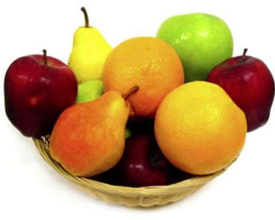

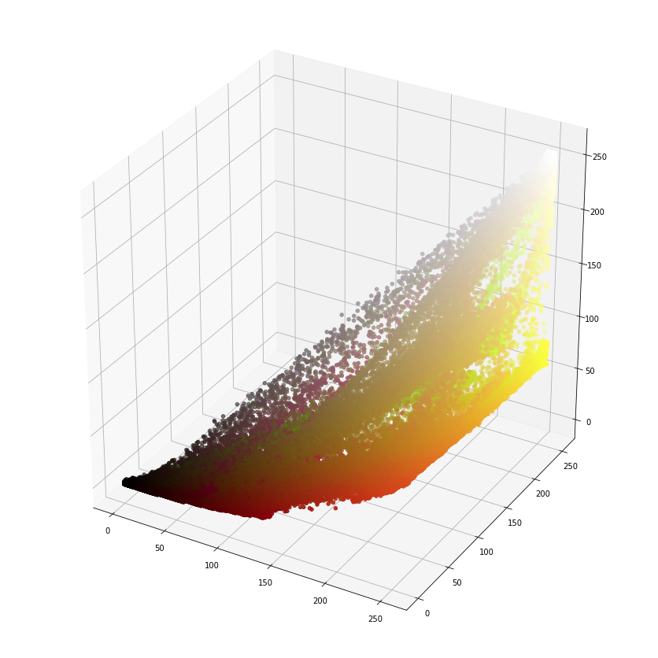

```python
img = imread("imgs/L938.png")
imshow(img)
plot_in_rgb_space(img)
```

## Red Filter Example

[figure not shown]

Fig 11

```python
def cfilter(img,r,g,b):
    img2 = img.copy()
    img2[(img2[:,:,0] > r) | (img2[:,:,1] > g) | (img2[:,:,2] > b)] = [255,255,255]
    return img2
```

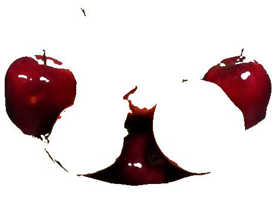

```python
imshow(cfilter(img,255,50,50))
```

## Seperate Intensity and Color

### How intensity affects color values

[figure not shown]

Fig 12(a): Just different shades of green, but all 3 values change

### Solution: Seperate intensity and color

[figure not shown]

Fig 12(b)

Define intensity ($\color{blue}{Y}$) as some combination of $\color{blue}{R}$,$\color{blue}{G}$,$\color{blue}{B}$

$$\color{blue}{Y = W_R\times R + W_G \times G + W_B \times B}$$

$$\color{blue}{= 0.299\times R + 0.587 \times G + 0.114 \times B}$$

Then compute new color values, taking out intensity

$$\color{blue}{V = V_{max}\frac{R-Y}{1-W_R} \approx 0.877 \times (R-Y)}$$

Assuming $\color{blue}{R}$,$\color{blue}{G}$,$\color{blue}{B}$ and $\color{blue}{Y}$ are in the range $\color{blue}{[0,1]}$

$$\color{blue}{U \in [-U_{max}, U_{max}]}\color{black}{\text{ and }}\color{blue}{V \in [-V_{max}, V_{max}]}$$

[figure not shown]

Fig 12(c)

```python
import cv2
import numpy as np
def make_lut_u():
    return np.array([[[i,255-i,0] for i in range(256)]],dtype=np.uint8)
def make_lut_v():
    return np.array([[[0,255-i,i] for i in range(256)]],dtype=np.uint8)


img_yuv = cv2.cvtColor(img, cv2.COLOR_BGR2YUV)
y, u, v = cv2.split(img_yuv)

lut_u, lut_v = make_lut_u(), make_lut_v()

# Convert back to BGR so we can apply the LUT and stack the images
y = cv2.cvtColor(y, cv2.COLOR_GRAY2BGR)
u = cv2.cvtColor(u, cv2.COLOR_GRAY2BGR)
v = cv2.cvtColor(v, cv2.COLOR_GRAY2BGR)
```

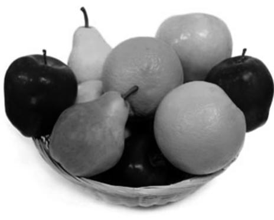

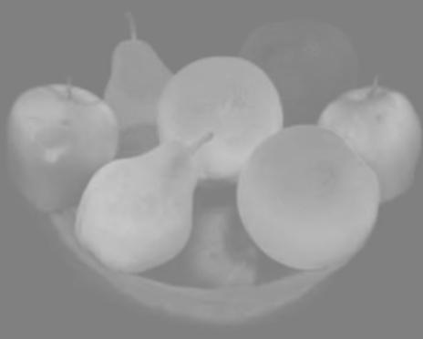

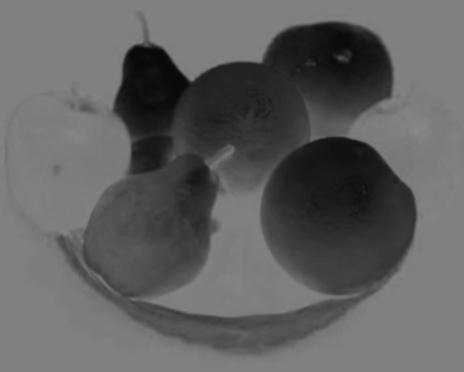

```python
imshow(y)
imshow(u)
imshow(v)
```

## YUV Color Distribution

[figure not shown]

Fig 13(a)

[figure not shown]

Fig 13(b)

### Quiz: UV Filter Quiz

[figure not shown]

Fig 13(c)

What UV limits should we use to extract red regions?

Filter:

## UV and YUV Filters

[figure not shown]

Fig 14(a)

[figure not shown]

Fig 14(b)

[figure not shown]

Fig 14(c)

[figure not shown]

Fig 14(d)

### Comparing RGB and YUV filters

[figure not shown]

Fig 14(e)

```python
def yuvfilter_cv(yuvimg,ymin,ymax,umin,umax,vmin,vmax):
    i = yuvimg.copy()
    img2[(i[:,:,0] < ymin) | (i[:,:,0] > ymax) | (i[:,:,1] < umin) | (i[:,:,1] > umax) | (i[:,:,2] < vmin) | (i[:,:,2] > vmax)] = [255,255,255]
    return img2
```

```
RGB Color Filter
```

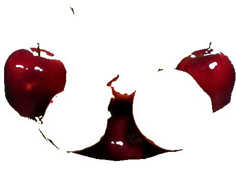

```
YUV Filter
```

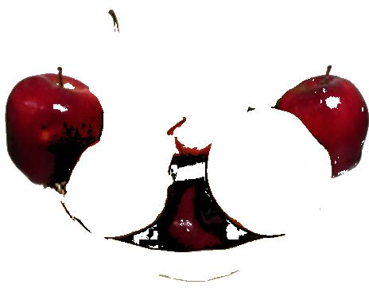

```python
print("RGB Color Filter")
imshow(cfilter(img,255,50,50))
yuv_img = cv2.cvtColor(img, cv2.COLOR_BGR2YUV)
print("YUV Filter")
imshow(yuvfilter_cv(yuv_img,0,150,130,200,100,130))
```

## Intuition and Other Luma Chroma Color Spaces

### Why YUV?

- Easier clustering of pixels
- Efficient encoding by *Chroma subsampling*
  - Recall, human vision is more sensitive to intensity changes
  - Y channel can now use more bits
- E.g., YUV422 - to represent 2 image pixels, it uses 2 bytes for Y, and 1 byte each for U and V

### Other luma-chroma color spaces

- $YC_bC_r/YP_bP_r$ - video transmission, compression
- CIE L*a*b*
  - Based on human perception
  - Intensity channel: L* = lightness
  - Color-opponent: a *= red-green, b* = blue-yellow
- CIE L*uv* - like L*a*b* but easier to compute

### Back to plotting image pixels (Plotting in HSV)

[figure not shown]

Fig 15(a)

Focus on HS projection

- What do you see?

Colors spread along a single dimension! *Hue*

### A better HS plot

Treat hue as an angle

- Reds from both ends of the spectrum now in proximity
- Better reflects the role of saturation (radius or distance from center)

[figure not shown]

Fig 15(b)

# =====================================

# 9A-L2 Segmentation

# =====================================

## Segmentation of Coherent Regions

[figure not shown]

Fig 16(a): Berkeley segmentation database

### Figure Ground Segmentation

- Seperate the forground object (figure) from the background (ground)

[figure not shown]

Fig 16(b)

### Grouping of Similar Neighbors

[figure not shown]

Fig 16(c): Superpixels

### Extends Beyond Single Images

[figure not shown]

Fig 16(d)

## Noisy Image

### Image segmentation: Toy example

[figure not shown]

Fig 17(a)

[figure not shown]

Fig 17(b): with noise

How to determine the three main intensities that define our groups?

- We need to *cluster*.

## Clustering

- Goal: choose three "centers" as the **representative** intensities, and label every pixel according to which of these centers it is nearest to.

[figure not shown]

Fig 18(a)

- Best cluster centers are those that **minimize SSD** between all points and their nearest cluster center $c_i$:

$$\color{blue}{SSD = \sum_{cluster\, C_i}\sum_{p \in C_i}||P_j - c_i||^2}$$

- With this objective, it is a "chicken and egg" problem:
  - Q: If we know $c_i$'s, how would we determine which points to associate with each **cluster center**?
  - A: for each point p, choose **closest** $c_i$

[figure not shown]

Fig 18(b)

- With this objective, it is a "chicken and egg" problem:
  - Q: If we knew the **cluster membership**, how do we get the centers? ?
  - A: choose $c_i$ to be the **mean** of all points in the cluster

[figure not shown]

Fig 18(c)

## K-means Clustering

1. Randomly intialize cluster centers $\color{blue}{c_1,...,c_K}$
2. Determine points in each cluster:
   - For each point $\color{blue}{p}$, find the closest $\color{blue}{c_i}$; put $\color{blue}{p}$ into cluster $\color{blue}{i}$
3. Given points in each cluster, solve for $\color{blue}{c_i}$:
   - Set $\color{blue}{c_i}$ to be the mean of points in cluster $\color{blue}{i}$
4. If any $\color{blue}{c_i}$ has changed, repeat **Step 2**

[figure not shown]

Fig 19

```python
import cv2
import numpy as np
def kmeans(image,segments):
    """
        1. samples : It should be of np.float32 data type, and each feature should be put in a single column.

        2. nclusters(K) : Number of clusters required at end

        3. criteria : It is the iteration termination criteria. When this criteria is satisfied,
                      algorithm iteration stops. Actually, it should be a tuple of 3 parameters.
                      They are ( type, max_iter, epsilon ):

                        3.a - type of termination criteria : It has 3 flags as below:
                                cv2.TERM_CRITERIA_EPS - stop the algorithm iteration if specified accuracy, epsilon, is reached.
                                cv2.TERM_CRITERIA_MAX_ITER - stop the algorithm after the specified number of iterations, max_iter.
                                cv2.TERM_CRITERIA_EPS + cv2.TERM_CRITERIA_MAX_ITER - stop the iteration when any of the above condition is met.

                        3.b - max_iter - An integer specifying maximum number of iterations.

                        3.c - epsilon - Required accuracy

        4. attempts : Flag to specify the number of times the algorithm is executed using different initial labellings.
                      The algorithm returns the labels that yield the best compactness.
                      This compactness is returned as output.
        5. flags : This flag is used to specify how initial centers are taken. Normally two flags are
                  used for this : cv2.KMEANS_PP_CENTERS and cv2.KMEANS_RANDOM_CENTERS.
    """
    image=cv2.GaussianBlur(image,(7,7),0)
    vectorized=image.reshape(-1,3)
    vectorized=np.float32(vectorized)
    criteria=(cv2.TERM_CRITERIA_EPS + cv2.TERM_CRITERIA_MAX_ITER, 10, 1.0)
    ret,label,center=cv2.kmeans(vectorized,segments,None,criteria,10,cv2.KMEANS_RANDOM_CENTERS)
    res = center[label.flatten()]
    segmented_image = res.reshape((image.shape))
    return label.reshape((image.shape[0],image.shape[1])),segmented_image.astype(np.uint8)

def extractComponent(image,label_image,label):
    component=np.zeros(image.shape,np.uint8)
    component[label_image==label]=image[label_image==label]
    return component
```

```python
def segment(image,segments=3):
    label,result= kmeans(image,segments=segments)
    imshow(result)
```

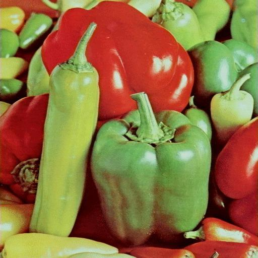

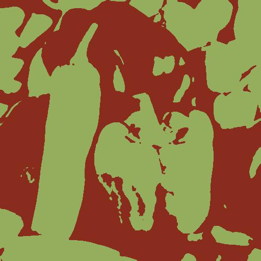

```python
image=imread("imgs/peppers.jpg")
imshow(image)
segment(image,2)
```

[figure not shown]

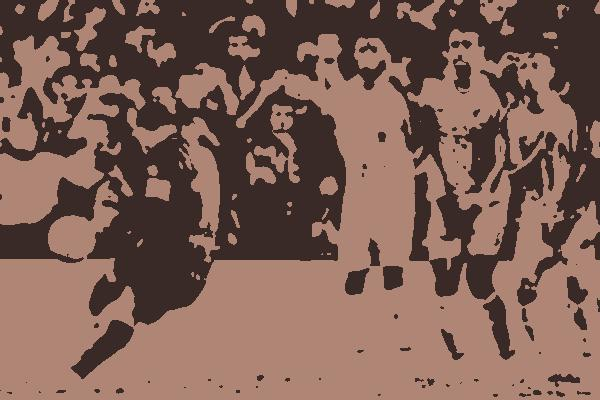

[figure not shown]

[figure not shown]

[figure not shown]

[figure not shown]

[figure not shown]

[figure not shown]

[figure not shown]

[figure not shown]

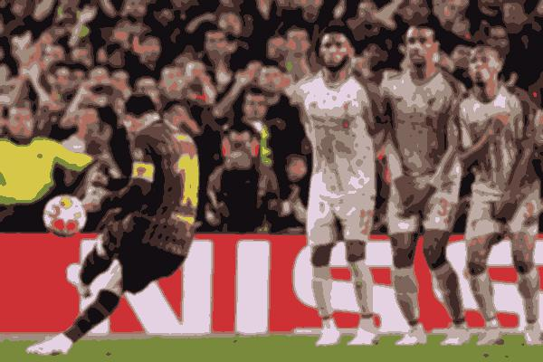

[figure not shown]

[7 more figures not shown]

```python
messi = imread("imgs/messi_liverpool.jpg")
imshow(messi)
for i in range(2,20):
    segment(messi,i)
```

## Number of Clusters

### Segmentation as clustering

Depending on what we choose as the *feature space*, we can group pixels in different ways

- Grouping pixels based on **intensity similarity**

[figure not shown]

Fig 20(a): Feature space: intensity value (1-d)

[figure not shown]

Fig 20(b)

Can be thought of as *quantization* of the feature space; segmentation label map

## Segmentation as Clustering

Depending on what we choose as the *feature space*, we can group pixels in different ways.

Grouping pixels based on **color**similarity.

[figure not shown]

Fig 21(a): Feature space: color value (3-d)

K-means clustering based on intensity or color is essentially vector quantization of the image attributes

[figure not shown]

Fig 21(b)

Grouping pixels based on *intensity+position* similarity

[figure not shown]

Fig 21(c)

Can combine color and location...

[figure not shown]

Fig 21(d)

## Pros and Cons

- Pros
  - Very simple method
  - Converges to a local minimum of the error function
- Cons
  - Memory-intensive
  - Need to pick K
  - Sensitive to intialization
  - Sensitive to outliers
  - Only finds "spherical" clusters

[figure not shown]

Fig 22: spherical problem with k-means

# =====================================

# 9A-L3 Mean shift Segmentation

# =====================================

### Mean Shift Algorithm

The mean shift algorithm seeks **modes** or local maxima of density in the feature space

[figure not shown]

Fig 23

## Mean Shift Space

[figure not shown]

Fig 24

## Mean Shift Clustering

- Cluster: all data points in the **attraction basin** of a mode
- **Attraction basin**: the region for which all trajectories lead to the same mode

[figure not shown]

Fig 25(a)

- Find features( color, gradients, texture, etc.)
- Initialize window at individual feature points(pixels)
- Perform mean shift for each window (pixel) until convergence
- Merge windows (pixels) that end up near the same "peak" or mode

[figure not shown]

Fig 25(b)

## Mean Shift Segmentation Results

[figure not shown]

Fig 26

```python
## You need to install pymeanshift from https://github.com/fjean/pymeanshift
import cv2
import pymeanshift as pms
```

```python
original_image = imread("imgs/peppers.jpg")
```

```python
segmented_image, labels_image, number_regions = pms.segment(original_image, spatial_radius=6,
                                                              range_radius=4.5, min_density=50)
```

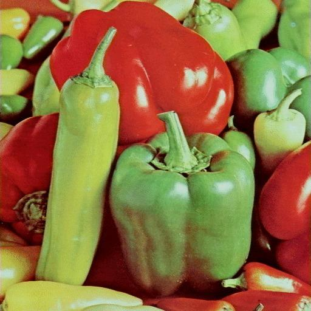

```
Number of segments 1042
```

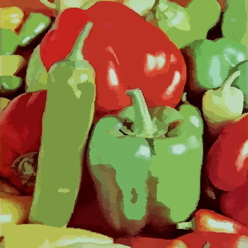

```python
imshow(original_image)
print("Number of segments %d" % number_regions)
imshow(segmented_image)
```

```python
messi = imread("imgs/messi_liverpool.jpg")
segmented_messi, labels_image, number_regions = pms.segment(messi, spatial_radius=6,
                                                              range_radius=4.5, min_density=50)
```

[figure not shown]

```
Number of segments 1580
```

[figure not shown]

```python
imshow(messi)
print("Number of segments %d" % number_regions)
imshow(segmented_messi)
```

## It is so sad... Barcelona lost the second leg against Liverpool FC horribly. They were out of the champions league. Messi showed signs of aging weekness. The hero is dying... The story is about to end

[figure not shown]

## Pros and Cons

Pros:

- Automatically finds basin of attraction
- One parameter choice (window size)
- Does not assume (image) shape on clusters
- Generic technique
- Find multiple modes

Cons:

- Selection of window size
- Does not scale well with dimension of feature space

## Segmentation as Clustering

Color, brighness, position alone are not enough to distinguish all regions...

[figure not shown]

Fig 27(a)

Grouping pixels based on texture similarity

[figure not shown]

Fig 27(b) Feature space: filter bank responses (e.g. 24D)

### Texture representation example

[figure not shown]

Fig 27(c)

## Texture Features

- Find "textons" by clustering vectors of filter bank outputs
- Describe texture in a window based on its **texton histogram**

[figure not shown]

Fig 28(a)

[figure not shown]

Fig 28(b)

### Examples

[figure not shown]

Fig 28(c)

# =====================================

# 9A-L4 Segmentation by Graph Partitioning

# =====================================

## Measuring Affinity

[figure not shown]

Fig 29(a)

Fully-connected graph

- 1 node (vertex) for every pixel
- A link between *every pair* of pixels $\color{blue}{<}\color{green}{p}\color{blue}{\text{, }}\color{orange}{q}\color{blue}{>}$
- Affinity weight $\color{maroon}{W_{pq}}$ for each linke (edge)
  - $\color{maroon}{W_{pq}}$ measures similarity: Inversely proportional to difference (in color and position...)

$$\color{blue}{\text{aff}(x_i,x_j) = exp \left ( -\frac{1}{2\sigma^2}dist(x_i,x_j)^2 \right ) }$$

[figure not shown]

Fig 29(b)

## Segmentation by Graph Partitioning

[figure not shown]

Fig 30

Break Graph into segments

- Delete links that cross between segments
- Easiest to break links with low affinity

Results

- Similar pixels should be in the same segments
- Dissimilar pixels should be in different segments

## Graph Cut

$$\color{blue}{cut(A,B) = \sum_{p\in A,q\in B}w_{pq}}$$

- Set of edges whose removal makes a graph disconneted
- Cost of a cut: Sum of weights of cut edges

A graph cut gives us a segmentaion

- What is a "good" graph cut and how do we fine one?

[figure not shown]

Fig 31(a)

Find minimum cut

- Gives you a segmentation
- Fast min-cut algorithms exist

### Minimum cut

Problem with min cut:

- Weight of cut proportional to number of edges in the cut
- Tends to produce small, isolated components

[figure not shown]

Fig 31(b)

## Normalized cut

Fix bias of min cut by normalizing for size of segments:

$$\color{blue}{Ncut(A,B) = \frac{cut(A,B)}{assoc(A,V)} + \frac{cut(A,B)}{assoc(B,V)}}$$

$\color{blue}{assoc(A,V)}$ = sum of weights of all edges that touch A

Approximate solution for minimizing the *Ncut* value: *Generalized eigenvalue problem*

### Normalized cut

- Then the normalized cut cost can be written as

### Normalized cut algorithm

1. Represent the image as a weighted graph $\color{blue}{G = (V,E)}$, compute weight of each edge and summarize in $\color{blue}{D}$ and $\color{blue}{W}$
2. Solve $\color{blue}{(D-W)y = \lambda Dy}$ for the eigenvector with the second smallest eigenvalue
3. Use the entries of the eigenvector to bipartition the graph

## Results

[figure not shown]

Fig 32 [Berkeley Segmentation Engine](http://www.cs.berkeley.edu/~fowlkes/BSE/)

GrabCut algorithm was designed by Carsten Rother, Vladimir Kolmogorov & Andrew Blake from Microsoft Research Cambridge, UK. in their paper, "GrabCut": interactive foreground extraction using iterated graph cuts . An algorithm was needed for foreground extraction with minimal user interaction, and the result was GrabCut.

[figure not shown]

[output not shown]

```python
import numpy as np
import cv2
from matplotlib import pyplot as plt

img = imread('imgs/messi5.jpg')
mask = np.zeros(img.shape[:2],np.uint8)

bgdModel = np.zeros((1,65),np.float64)
fgdModel = np.zeros((1,65),np.float64)

rect = (50,50,450,290)
cv2.grabCut(img,mask,rect,bgdModel,fgdModel,1,cv2.GC_INIT_WITH_RECT)

mask2 = np.where((mask==2)|(mask==0),0,1).astype('uint8')
img = img*mask2[:,:,np.newaxis]

plt.imshow(img),plt.colorbar(),plt.show()
```

[figure not shown]

[output not shown]

```python
img = imread('imgs/messi5.jpg')
# newmask is the mask image I manually labelled
newmask = imread('grabcut_mask.png')[:,:,0]
# whereever it is marked white (sure foreground), change mask=1
# whereever it is marked black (sure background), change mask=0
mask[newmask == 0] = 0
mask[newmask == 255] = 1

mask, bgdModel, fgdModel = cv2.grabCut(img,mask,None,bgdModel,fgdModel,5,cv2.GC_INIT_WITH_MASK)
mask2 = np.where((mask==2)|(mask==0),0,1).astype('uint8')
img = img*mask2[:,:,np.newaxis]
plt.imshow(img),plt.colorbar(),plt.show()
```

## Pros and Cons

Pros:

- Generic framework
  - Flexible to choice of function that computes weights ("affinities") between nodes
- Does not require model of the data distribution

Cons:

- Time complexity can be high
  - Dense, highly connected graphs $\rightarrow$ many affinity computation
  - Solving eigenvalue problem
- Preference for balanced partitions

[figure not shown]

Sad Messi after the second goal against Getafe. I have never read a story or watched a movie where the hero promise something and doesn't deliver it at the end. Appearntly the reality doesn't make sense and fiction is the correct adjusment of its logic

# =====================================

# 9B-L1 Binary Morphology

# =====================================

## Binary Image Analysis

Operations that produce or process binary images, typically 0's and 1's

- 0 represents background
- 1 represents forground

[figure not shown]

Fig 33(a)

### Binary Image Analysis

Used in a number of practical applications

- Part inspection
- Manufacturing
- Document processing

[figure not shown]

Fig 33(b)

## Kinds of Operation

- Seperate objects from background and from one another
- Aggregate pixels for each object
- Compute features for each object

### Example: Red blood cell image

[figure not shown]

Fig 34(a)

- Many blood cells are seperate objects
- Many touch - bad!
- Salt and pepper noise from thresholding
- How useable is this data

### Results of analysis

[figure not shown]

Fig 34(b)

- 63 separate objects detected
- Single cells have area about 50
- Noise spots
- Gobs of cells

### Useful Operations

- Thesholding a gray-scale image
- Determine good threshold
- Connected components analysis
- All sorts of feature extractors, statistics (area, centroid, circularity, ...)

## Thresholding

[figure not shown]

Fig 35(a)

- Background is black
- Healthy cherry is bright
- Bruise is medium dark
- Histogram shows two cherry regions (black background has been removed)

### Histogram-Directed Thresholding

How can we use a histogram to separate an image into 2 (or several) different regions?

[figure not shown]

Fig 35(b): Is there a single clear threshold? 2? 3?

### Automatic Thresholding: Otsu's Method

Assumption: The histogram is bimodal

[figure not shown]

Fig 35(c)

Method: Find the threshold $\color{blue}{t}$ that minimizes the weighted sum of within-group variances for the two groups that result from separating the gray tones at value $\color{blue}{t}$

## Thresholding Example

[figure not shown]

Fig 36(a)

### Connected Components Labeling

Once you have a binary image, you can identify and then analyze each connected set of pixels

[figure not shown]

Fig 36(b)

## Connected Components

### Methods

1. Recursive Tracking (almost never used)
2. Parallel Growing (needs parallel hardware)
3. Row-by-Row (most common)
   - Classical Algorithm
   - Efficient Run-Length Algorithm (developed for speed in real industrial applications)

### Algorithm

- CC = 0
- Scan across rows:
  - IF 1 and connected:
    - Propgate lowest label behind or above (4 or 8 connected). Remember conflicts
  - If 1 and not connected:
    - CC++ and label CC
  - If 0:
    - Label 0
- Relabel based on table

[figure not shown]

Fig 37(a)

### Results

[figure not shown]

Fig 37(b): Connected components of 1's from thresholded image

[figure not shown]

Fig 37(b): Connected components of cluster labels

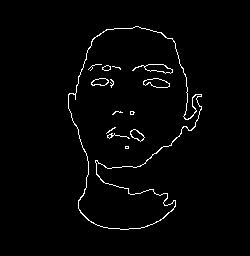

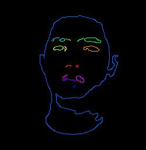

```python
## from: https://stackoverflow.com/questions/46441893/connected-component-labeling-in-python
## it takes sometime
import cv2
import numpy as np

img = cv2.imread('imgs/eGaIy.jpg', 0)
img = cv2.threshold(img, 127, 255, cv2.THRESH_BINARY)[1]  # ensure binary
ret, labels = cv2.connectedComponents(img)

def imshow_components(labels):
    # Map component labels to hue val
    label_hue = np.uint8(179*labels/np.max(labels))
    blank_ch = 255*np.ones_like(label_hue)
    labeled_img = cv2.merge([label_hue, blank_ch, blank_ch])

    # cvt to BGR for display
    labeled_img = cv2.cvtColor(labeled_img, cv2.COLOR_HSV2BGR)

    # set bg label to black
    labeled_img[label_hue==0] = 0
    imshow(img)
    imshow(labeled_img)

imshow_components(labels)
```

## Dilation and Erosion

### Mathematical Morphology

Two basic operations

- Dilation
- Erosion

And several composite relations

- Closing and opeining
- Thinning and thickening ...

### Dilation

Dilation expands the connected sets of 1s of a binary image.

It can be used for:

- Growing features
- Filling holes and gaps

[figure not shown]

Fig 38(a)

### Errosion

Erosion shrinks the connected sets of 1s of a binary image.

It can be used for:

- Shrinking features
- Removing bridges, branches, protrusions

[figure not shown]

Fig 38(b)

```python
# Python program to demonstrate erosion and
# dilation of images.
import cv2
import numpy as np

# Reading the input image
jimg = imread('imgs/j.png')[:,:,0]

# Taking a matrix of size 5 as the kernel
kernel = np.ones((5,5), np.uint8)

img_erosion = cv2.erode(jimg, kernel, iterations=1)
img_dilation = cv2.dilate(jimg, kernel, iterations=1)

print("Original")
imshow(jimg)
print("Eroded")
imshow(img_erosion)
print("dilated")
imshow(img_dilation)
```

```
Original
```

```
Eroded
```

```
dilated
```

```
Original
```

```
Eroded
```

[figure not shown]

```
dilated
```

[figure not shown]

```python
# dilation of images.
import cv2
import numpy as np

# Reading the input image
sadmessi = imread('imgs/sad_messi.jpg')[:,:,0]

# Taking a matrix of size 5 as the kernel
kernel = np.ones((5,5), np.uint8)

img_erosion = cv2.erode(sadmessi, kernel, iterations=1)
img_dilation = cv2.dilate(sadmessi, kernel, iterations=1)

print("Original")
imshow(sadmessi)
print("Eroded")
imshow(img_erosion)
print("dilated")
imshow(img_dilation)
```